# An example pipeline for estimating DNAm age with different models for arbitrary methylation data

## Loading necessary python packages

For the tutorial below, we are going to use the following python packages:

- [`pandas`](https://pandas.pydata.org/) for dataframe manipulation
- [`matplotlib`](https://matplotlib.org/) for plotting
- [`numpy`](https://numpy.org/) for basic calculations

```python
import pandas as pd
import matplotlib.pyplot as plt
import numpy as np
%matplotlib inline
```

## Loading model parameters

Model parameters are stored in Supplementary file 3, but can also be loaded from the following github URL:

`https://raw.githubusercontent.com/pipekorsi/MepiClock/main/resources/model_coefficients.csv`

```python
df_model_coeff = pd.read_csv("https://raw.githubusercontent.com/pipekorsi/MepiClock/main/resources/model_coefficients.csv",
                            sep = ";")
```

The first few raws of the dataframe show its basic structure. Coefficient values equal to zero represent CpG probes not included in the covariates of the given model.

```python
df_model_coeff.head()
```

|  | probeID | elasticNet (239) | filtered H (272) | retrained H (308) | original H (336) |
| --- | --- | --- | --- | --- | --- |
| 0 | (Intercept) | 0.336142 | 0.693633 | 0.632194 | 0.695507 |
| 1 | cg00027083 | 0.143973 | 0.000000 | 0.000000 | 0.000000 |
| 2 | cg00059225 | 1.480154 | 0.000000 | 0.000000 | 0.000000 |
| 3 | cg00075967 | 0.032254 | 0.228816 | 0.155078 | 0.129337 |
| 4 | cg00091693 | 0.000000 | -0.237786 | -0.291876 | -0.002008 |

## Loading methylation dataset

### Checking metadata

In this tutorial we are going to use one of the methylation datasets included in the test data used for accessing model performance. Its GEO accession number is `GSE152026` and basic metadata of the study can be checked at the [GEO accession viewer](https://www.ncbi.nlm.nih.gov/geo/query/acc.cgi?acc=GSE152026):

> **Blood DNA methylation profiles from first episode psychosis patients and controls**

> Genome-wide patterns of DNA methylation were quantified using the Illumina Infinium HumanMethylationEPIC BeadChip (“EPIC array”) in DNA samples isolated from blood for schizophrenia cases, first episode psychosis patients and controls. These samples were profiled as part of a wider study where they were meta-analysed with other cohorts.

Apparently, the Illumina Infinium HumanMethylationEPIC BeadChip was used to generate methylation data, thus we expect to have around 850K measurement points for each sample.

To check basic metadata, we can download the "Series Matrix" file with:

!wget https://ftp.ncbi.nlm.nih.gov/geo/series/GSE152nnn/GSE152026/matrix/GSE152026_series_matrix.txt.gz

Checking basic file structure:

```python
!zcat GSE152026_series_matrix.txt.gz | head
```

```
!Series_title	"Blood DNA methylation profiles from first episode psychosis patients and controls I"
!Series_geo_accession	"GSE152026"
!Series_status	"Public on Apr 07 2021"
!Series_submission_date	"Jun 08 2020"
!Series_last_update_date	"Apr 07 2021"
!Series_pubmed_id	"33646943"
!Series_summary	"Genome-wide patterns of DNA methylation were quantified using the Illumina Infinium HumanMethylationEPIC BeadChip (“EPIC array”) in DNA samples isolated from blood for schizophrenia cases, first episode psychosis patients and controls. These samples were profiled as part of a wider …
!Series_overall_design	"This data includes 934 adult samples profiled as part of a psychosis case control study design. Specifically it includes data for 458 first-episode psychosis (FEP) cases and 558 controls recruited as part of the EU-GEI study."
!Series_type	"Methylation profiling by array"
!Series_contributor	"E,,Hannon"

gzip: stdout: Broken pipe
```

The samples in this dataset are either from patients suffering from schizophrenia or control cases. In our analysis, only the control cases will be needed. We will also need the chronological age of the patients to be able to test model performance. Here we extract age and sample name for control cases (with available age information) and store them in a dataframe:

```python
tmp = !zcat GSE152026_series_matrix.txt.gz | grep "characteristics_ch1" | grep "phenotype"
phenotype = tmp[0].split("\t")[1:]

tmp = !zcat GSE152026_series_matrix.txt.gz | grep "characteristics_ch1" | grep "age"
age = tmp[0].split("\t")[1:]

tmp = !zcat GSE152026_series_matrix.txt.gz | grep "Sample_title"
sample_name = tmp[0].split("\t")[1:]

sample_metadata_df = pd.DataFrame()
sample_metadata_df["sampleName"] = [sample_name[i].split(" ")[0].replace('"', '')
                                    for i in range(len(sample_name)) if "Control" in phenotype[i] and "NA" not in age[i]]
sample_metadata_df["age"] = [int(age[i].split(": ")[1].replace('"',''))
                             for i in range(len(sample_name)) if "Control" in phenotype[i] and "NA" not in age[i]]
```

```python
sample_metadata_df.head()
```

|  | sampleName | age |
| --- | --- | --- |
| 0 | 200889820112_R01C01 | 63 |
| 1 | 200889820112_R05C01 | 54 |
| 2 | 200889820112_R07C01 | 31 |
| 3 | 200889820112_R08C01 | 42 |
| 4 | 200889820117_R01C01 | 44 |

The number of remaining samples:

```python
sample_metadata_df.shape[0]
```

```
519
```

### Downloading raw methylation data

Unfortunately, the "Series Matrix" file does not contain actual measurement data for this dataset, thus the raw data needs to be downloaded and preprocessed.

We downloaded the `GSE152026_EUGEI_processed_signals.csv.gz` file from the GEO ftp site on a Linux system with:

%%bash cd data/GSE152026 wget https://ftp.ncbi.nlm.nih.gov/geo/series/GSE152nnn/GSE152026/suppl/GSE152026_EUGEI_processed_signals.csv.gz

Checking the first few rows and columns of the downloaded datafile reveals that both the $\beta$-values and the detection p-values are recorded and samples are referred to by their sentrix position and chip ID:

```python
!zcat data/GSE152026/GSE152026_EUGEI_processed_signals.csv.gz | head -2 | cut -d',' -f1,2,3,4,5
```

```
"","200863670076_R01C01","200863670076_R01C01_Detection_Pval","200863670076_R02C01","200863670076_R02C01_Detection_Pval"
"cg00000029",0.37937352230886,1.62762280961683e-26,0.444926666863015,1.47456418339601e-85

gzip: stdout: Broken pipe
```

Checking the number of lines is in agreement with our previous knowledge that the samples were processed on the EPIC array:

```python
!zcat data/GSE152026/GSE152026_EUGEI_processed_signals.csv.gz | wc -l
```

```
860964
```

Given that the epigenetic clock models only contain a couple hundred CpG sites, it is computationally more efficient to only load a dataset that was previously filtered for these probes and sample columns:

```python
probes_to_keep = [p for p in list(df_model_coeff["probeID"]) if "Intercept" not in p]
samples_to_keep = list(sample_metadata_df["sampleName"])

df_large_chunks = []
chunksize = 10000
with pd.read_csv("data/GSE152026/GSE152026_EUGEI_processed_signals.csv.gz",
                 sep=",", chunksize = chunksize) as reader:
    for chunk in reader:
        tmp = chunk[chunk["Unnamed: 0"].isin(probes_to_keep)][["Unnamed: 0"]+samples_to_keep].rename(
            columns={"Unnamed: 0":"probeID"})
        df_large_chunks.append(tmp)
        print(".", end="")
beta_df = pd.concat(df_large_chunks)
```

```
.......................................................................................
```

The loaded dataframe now contains methylation $\beta$-values for the 519 samples in the dataset for the relevant CpG probes included in the epigenetic clock models:

```python
beta_df.head()
```

|  | probeID | 200889820112_R01C01 | 200889820112_R05C01 | 200889820112_R07C01 | 200889820112_R08C01 | 200889820117_R01C01 | 200889820117_R03C01 | 200889820117_R04C01 | 200889820113_R03C01 | 200889820113_R05C01 | ... | 200970100058_R06C01 | 200970100059_R01C01 | 200970100059_R02C01 | 201118840089_R01C01 | 201118840089_R04C01 | 201118840089_R08C01 | 201118840090_R01C01 | 201118840090_R02C01 | 201118840090_R05C01 | 201118840090_R06C01 |
| --- | --- | --- | --- | --- | --- | --- | --- | --- | --- | --- | --- | --- | --- | --- | --- | --- | --- | --- | --- | --- | --- |
| 1038 | cg00027083 | 0.106244 | 0.089244 | 0.079449 | 0.161561 | 0.038202 | 0.521380 | 0.091682 | 0.052795 | 0.110489 | ... | 0.059754 | 0.094328 | 0.043707 | 0.086396 | 0.120250 | 0.248360 | 0.086584 | 0.154347 | 0.136312 | 0.072502 |
| 2202 | cg00059225 | 0.301325 | 0.293096 | 0.233191 | 0.345340 | 0.285896 | 0.463479 | 0.231833 | 0.247390 | 0.309707 | ... | 0.218911 | 0.268745 | 0.258702 | 0.301961 | 0.287390 | 0.294653 | 0.253915 | 0.285590 | 0.252125 | 0.229069 |
| 2789 | cg00075967 | 0.747515 | 0.680567 | 0.676211 | 0.726498 | 0.722555 | 0.638774 | 0.724802 | 0.704613 | 0.711525 | ... | 0.644006 | 0.738985 | 0.762168 | 0.718061 | 0.687439 | 0.692887 | 0.731487 | 0.679027 | 0.705893 | 0.702155 |
| 3374 | cg00091693 | 0.572506 | 0.630640 | 0.615251 | 0.604692 | 0.603156 | 0.577847 | 0.640738 | 0.629967 | 0.617432 | ... | 0.646571 | 0.616906 | 0.655195 | 0.595013 | 0.647405 | 0.619080 | 0.589352 | 0.619737 | 0.599536 | 0.594529 |
| 6134 | cg00168942 | 0.528983 | 0.453554 | 0.552676 | 0.549506 | 0.485452 | 0.542072 | 0.504910 | 0.530346 | 0.533264 | ... | 0.604358 | 0.578185 | 0.529856 | 0.463869 | 0.573477 | 0.470492 | 0.494423 | 0.541216 | 0.563709 | 0.513708 |

5 rows × 520 columns

## Predicting chronological age

Chronological age can be predicted with either of the four models found in the `model_coefficients.csv` file as the appropriate linear combination of methylation values plus the intercept. More precisely, a transformation of the chronological age is predicted by the models which needs to be transformed back to the original scale with the function below:

```python
def transform_prediction(pred_list, age_adult = 20):
    return [(1+age_adult)*np.exp(pred)-1 if pred < 0 else (1+age_adult)*pred+age_adult for pred in pred_list]
```

Here we perform the actual age predictions and append them to the metadata table:

```python
# prediction with "elasticNet (239)" model
probes_to_use = list(set(df_model_coeff["probeID"]).intersection(set(beta_df["probeID"])))
coeffs_to_use = np.array(list(df_model_coeff[df_model_coeff["probeID"].isin(probes_to_use)]["elasticNet (239)"]))

meth_values_for_agepred = np.matrix(beta_df[beta_df["probeID"].isin(probes_to_use)][samples_to_keep])
predage = transform_prediction(np.array(list(df_model_coeff["elasticNet (239)"])[0] +
                                        meth_values_for_agepred.transpose() @ coeffs_to_use).reshape(len(samples_to_keep)))
sample_metadata_df["predicted_age_elasticNet"] = predage

# prediction with "filtered H (272)" model
probes_to_use = list(set(df_model_coeff["probeID"]).intersection(set(beta_df["probeID"])))
coeffs_to_use = np.array(list(df_model_coeff[df_model_coeff["probeID"].isin(probes_to_use)]["filtered H (272)"]))

meth_values_for_agepred = np.matrix(beta_df[beta_df["probeID"].isin(probes_to_use)][samples_to_keep])
predage = transform_prediction(np.array(list(df_model_coeff["filtered H (272)"])[0] +
                                        meth_values_for_agepred.transpose() @ coeffs_to_use).reshape(len(samples_to_keep)))
sample_metadata_df["predicted_age_filteredH"] = predage

# prediction with "retrained H (308)" model
probes_to_use = list(set(df_model_coeff["probeID"]).intersection(set(beta_df["probeID"])))
coeffs_to_use = np.array(list(df_model_coeff[df_model_coeff["probeID"].isin(probes_to_use)]["retrained H (308)"]))

meth_values_for_agepred = np.matrix(beta_df[beta_df["probeID"].isin(probes_to_use)][samples_to_keep])
predage = transform_prediction(np.array(list(df_model_coeff["retrained H (308)"])[0] +
                                        meth_values_for_agepred.transpose() @ coeffs_to_use).reshape(len(samples_to_keep)))
sample_metadata_df["predicted_age_retrainedH"] = predage

# prediction with "original H (336)" model
probes_to_use = list(set(df_model_coeff["probeID"]).intersection(set(beta_df["probeID"])))
coeffs_to_use = np.array(list(df_model_coeff[df_model_coeff["probeID"].isin(probes_to_use)]["original H (336)"]))

meth_values_for_agepred = np.matrix(beta_df[beta_df["probeID"].isin(probes_to_use)][samples_to_keep])
predage = transform_prediction(np.array(list(df_model_coeff["original H (336)"])[0] +
                                        meth_values_for_agepred.transpose() @ coeffs_to_use).reshape(len(samples_to_keep)))
sample_metadata_df["predicted_age_originalH"] = predage
```

And finally plot the results:

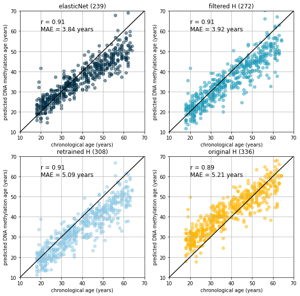

```python
plt.figure(figsize=(10,10))

r = round(np.corrcoef(sample_metadata_df["age"], sample_metadata_df["predicted_age_elasticNet"])[0,1],2)
MAE = round(np.median(np.abs(sample_metadata_df["age"]-sample_metadata_df["predicted_age_elasticNet"])),2)

plt.subplot(2, 2, 1)
plt.scatter(sample_metadata_df["age"], sample_metadata_df["predicted_age_elasticNet"], color="#023047", alpha=0.5)
plt.xlim(10,70)
plt.ylim(10,70)
plt.grid()
plt.xlabel("chronological age (years)")
plt.ylabel("predicted DNA methylation age (years)")
plt.title("elasticNet (239)")
plt.plot([10,70], [10,70], color="black")
plt.annotate("r = " + str(r) + "\nMAE = " + str(MAE) + " years", xy=(20,60), fontsize=12)

r = round(np.corrcoef(sample_metadata_df["age"], sample_metadata_df["predicted_age_filteredH"])[0,1],2)
MAE = round(np.median(np.abs(sample_metadata_df["age"]-sample_metadata_df["predicted_age_filteredH"])),2)

plt.subplot(2, 2, 2)
plt.scatter(sample_metadata_df["age"], sample_metadata_df["predicted_age_filteredH"], color="#219ebc", alpha=0.5)
plt.xlim(10,70)
plt.ylim(10,70)
plt.grid()
plt.xlabel("chronological age (years)")
plt.ylabel("predicted DNA methylation age (years)")
plt.title("filtered H (272)")
plt.plot([10,70], [10,70], color="black")
plt.annotate("r = " + str(r) + "\nMAE = " + str(MAE) + " years", xy=(20,60), fontsize=12)


r = round(np.corrcoef(sample_metadata_df["age"], sample_metadata_df["predicted_age_retrainedH"])[0,1],2)
MAE = round(np.median(np.abs(sample_metadata_df["age"]-sample_metadata_df["predicted_age_retrainedH"])),2)

plt.subplot(2, 2, 3)
plt.scatter(sample_metadata_df["age"], sample_metadata_df["predicted_age_retrainedH"], color="#8ecae6", alpha=0.5)
plt.xlim(10,70)
plt.ylim(10,70)
plt.grid()
plt.xlabel("chronological age (years)")
plt.ylabel("predicted DNA methylation age (years)")
plt.title("retrained H (308)")
plt.plot([10,70], [10,70], color="black")
plt.annotate("r = " + str(r) + "\nMAE = " + str(MAE) + " years", xy=(20,60), fontsize=12)

r = round(np.corrcoef(sample_metadata_df["age"], sample_metadata_df["predicted_age_originalH"])[0,1],2)
MAE = round(np.median(np.abs(sample_metadata_df["age"]-sample_metadata_df["predicted_age_originalH"])),2)

plt.subplot(2, 2, 4)
plt.scatter(sample_metadata_df["age"], sample_metadata_df["predicted_age_originalH"], color="#ffb703", alpha=0.5)
plt.xlim(10,70)
plt.ylim(10,70)
plt.grid()
plt.xlabel("chronological age (years)")
plt.ylabel("predicted DNA methylation age (years)")
plt.title("original H (336)")
plt.plot([10,70], [10,70], color="black")
plt.annotate("r = " + str(r) + "\nMAE = " + str(MAE) + " years", xy=(20,60), fontsize=12)

plt.show()
```